# Clustering P450s by % identity

Cytochrome P450 sequences form WCR and *Tribolium* were aligned using PRALINE. Next we need to cluster the sequences based on % identity assign clusters to CYP families.

# Functions

Compute % identity for a pair of aligned seqs. Note that because this is a multiple alignement, any 2 seqs may both have a gap at the same position. These shared gaps should not contribute to the % identity calculation

```r
pc.Identity <- function(seq1, seq2){
  s1 <- str_split(seq1[1], pattern = "", simplify = T)[1,]
  s2 <- str_split(seq2[1], pattern = "", simplify = T)[1,]
  sharedGaps <- (s1 == "-") & (s2 == "-")
  s1 <- s1[!sharedGaps]
  s2 <- s2[!sharedGaps]
  identicalResidues <- sum(s1 == s2)
  return((identicalResidues / length(s1)) * 100)
  }
```

# Load required libs

```r
library(seqinr)
library(stringr)
library(purrr)
```

# Load in the sequences from the aligned fasta file.

```r
#alignFile <- "test.fasta"
alignFile <- "PralineResults20201120/alignment.fasta_ali"
seqs <- read.fasta(file = alignFile,
                   seqtype = "AA",
                   as.string = T)
seqs <- unlist(seqs)
```

# Seq up all pairwise combinations of sequences.

This is not an efficient way to do things as there is some redundancy, but it’s easier to follow.

```r
tmp1 <- rep(seqs, times = length(seqs))
tmp2 <- rep(seqs, each = length(seqs))
dat <- data.frame(name1 = names(tmp1),
                  seq1 = tmp1,
                  name2 = names(tmp2),
                  seq2 = tmp2,
                  stringsAsFactors = F)
```

# Compute % identity for each sequence pair

```r
dat$pc.ID <- unlist(map2(dat$seq1,
                         dat$seq2,
                         pc.Identity)
                    )
```

# Set up distance matrix

Heirarchical clustering requires a distance measure, use 100 - %Identity. First make a reulr matrix, then a `dist` object.

```r
dists <- matrix(100 - dat$pc.ID,
                ncol = length(seqs),
                byrow = F,
                dimnames = list(names(seqs), names(seqs))
                )
dists <- as.dist(dists)
```

# Cluster

The single-linkage method is the correct one to use here. It produces clustering in which each member of a cluster of height $h$ has a distance $d \leq h$ to at least one other member of the cluster. This allows for the possibility that for any given pair in a cluster, it is possible that $d \gt h$. This seems odd but actually corresponds to the rule for family assignment for CYPS, which is simply $\gt 40\%$ identity with another member of the family.

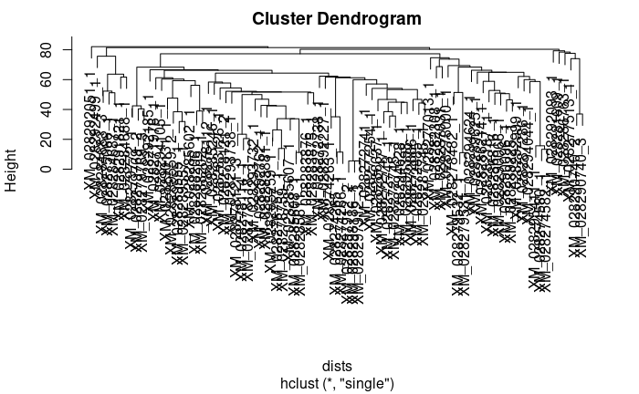

```r
clusts <- hclust(dists,
                 method = "single")
plot(clusts)
```

Not an especially readable plot, but shows things are working!

# Extract CYP family groups

CYP family membership criterion is 40%.

```r
cyp.fam.pc.id = 40
cyp.fams <- cutree(clusts,
                   h = 100 - cyp.fam.pc.id)
cyp.fams <- sort(cyp.fams)
```

```r
cyp.results <- data.frame(gene = names(cyp.fams),
                          group = cyp.fams)
```